# Working with Random Variables in R

Stat 241

## Median, Quantiles, Percentiles

We can summarize random variables with the median or other quantiles as well as with the mean and standard deviation.

If $X$ is a random variable, the median of $X$ is the number $m$ such that

$$\operatorname{P}(X \le m) = \frac{1}{2}$$

This is also called the 50th **percentile** or the 0.5 **quantile** because we can write $\frac{1}{2} =$ 50 % $= 0.5$. More generally, for any probability $p \in [0, 1]$, we can define the $p$-quantile as the number $q$ such that

$$\operatorname{P}(X \le q) = p$$

Unfortunately, for a discrete distribution, there might not be a value that satisfies this equation exactly (and if there is, it won’t be unique). So technically, our definition is a little bit more complicated. **The $p$-quantile of $X$ is the smallest number $q$ that has at least as much probability as specified by $p$:**

$$\operatorname{P}(X \le q) \ge p$$

**Example 1.** Let $X$ have the pdf $f(x) = 2x$ on $[0, 1]$. Find the median of $X$ and 20th percentile of $X$. Use integration in R to check your work.

We want to find $q$ so that

$$\int_0^q 2x \; dx = p$$
Let’s integrate and solve for $q$:

$$p = \int_0^q 2x \; dx = \left. x^2 \right|_0^q = q^2$$

So $q = \sqrt{p}$. The median is $\sqrt{0.5} - 0.707$ and the 20th percentile is $\sqrt{0.2} = 0.447$

We can check by integrating in R to see that we get the correct probabilities.

```r
f <- function(x) 2 * x * (0 <= x & x <= 1)
integrate(f, 0, sqrt(0.5))
```

```
## 0.5 with absolute error < 5.6e-15
```

```r
integrate(f, 0, sqrt(0.2))
```

```
## 0.2 with absolute error < 2.2e-15
```

# Important Families of Distributions

## Uniform Distributions (`unif`)

A uniform distribution is characterized by the interval on which it is defined. If the interval is $[a,b]$, then the pdf is $f(x) = \frac{1}{b-a}$ on $[a,b]$.

R has uniform distributions “built in”.

- `dunif(x, min, max)` computes the pdf at x (think: d for density)
- `punif(x, min, max)` computes the value of the cdf at x (think: p for probability)
- `qunif(p, min, max)` computes the qth quantile/percentile (think: q for quantile)
- `runif(n, min, max)` generates a random sample of n observations from the distribution. (think: r for random)

And ggformula inculdes a function called `gf_dist()` for plotting distributions. `gf_fun()` gives us a littel more control but makes us do more work.

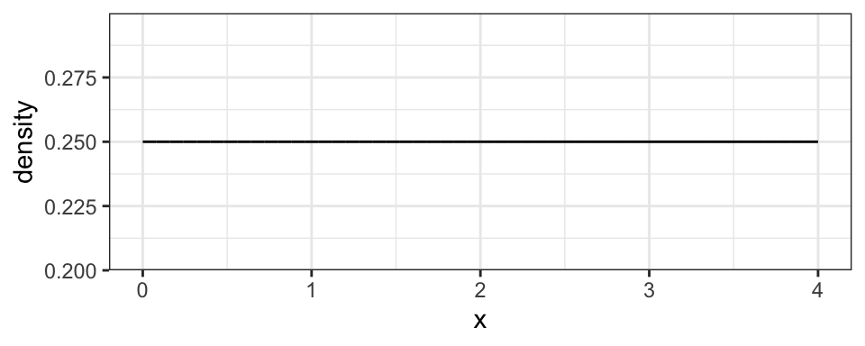

```r
gf_dist("unif", min = 0, max = 4)
```

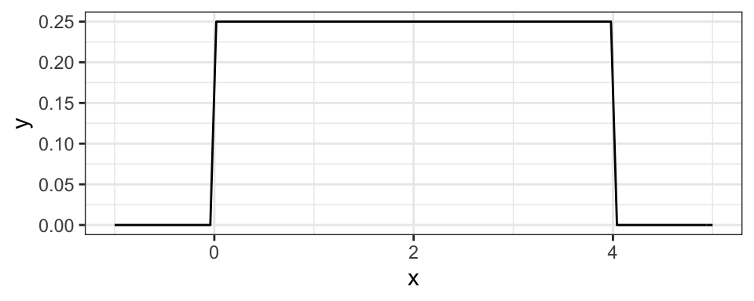

```r
gf_fun(dunif(x, 0, 4) ~ x, xlim = c(-1, 5))
```

```r
# P(1 ≤ X ≤ 3) = F(3) - F(1)
punif(3, 0, 4) - punif(1, 0, 4)
```

```
## [1] 0.5
```

```r
# 90th percentile = 0.9 - quantile
qunif(0.9, 0, 4)
```

```
## [1] 3.6
```

```r
# 10 random draws
runif(10, 0, 4)
```

```
##  [1] 3.5156023 2.6417307 2.5486521 2.2618935 1.1123892 3.5832004 3.0275199
##  [8] 1.2479071 3.4463927 0.8727829
```

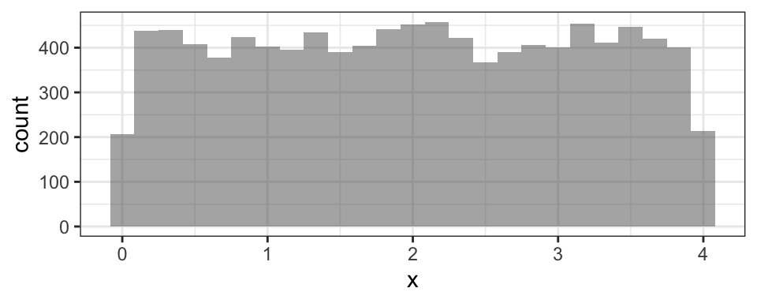

```r
# 10,000 random draws
x <- runif(10000, 0, 4)
gf_histogram(~ x)
```

For a uniform distribution, this is pretty boring – uniform distributions are easy to work with without the aid of R. But these same sorts of functions exist for many different families of distributions.